# Traffic flow analysis in AUSA toll booths

This project consists on analyzing the evolution of traffic on AUSA toll booths in Buenos Aires highways. The data being used in this project can be found on the [Buenos Aires Data](https://data.buenosaires.gob.ar/dataset/flujo-vehicular-por-unidades-de-peaje-ausa) site.

### Objective

The main aim of this project is being able to predict the amount of vehicles going in and out of the city for a given date in the future. So, if given a day $d_i$, the model will be able to predict the traffic volume on day $d_{i+1}$.

### Structure of the data to use

The information provided consists of 11 files, one for each year from 2008 to 2018. There is no strict convention on the columns naming, neither on whether categorical values are stored with uppercase letters or a mixture of uppercase and lowercase. To standardize everything to the same criteria, several transformations were performed.

The .csv files provide in each entry an estimate of the amount of vehicles that went through a certain toll both in an interval of time of one hour. The following is the detail of each column:

- PERIODO: indicates the **year**.
- FECHA: indicates the **full date** in *dd/mm/yyyy* format.
- DIA: indicates the **day of the week**.
- HORA: indicates the **start time of the interval**.
- HORA_FIN: indicates the **end time of the interval**.
- ESTACION: indicates the **name of the toll booth**.
- TIPO_VEHICULO: indicates whether the vehicle was a **truck or a car**.
- FORMA_PAGO: indicates if the **payment method**.
- CANTIDAD_PASOS: indicates the **number of vehicles** that went through the toll booth at that interval of time, and payed with a given payment method.

For example:

```r
df <- read.csv('~/Documents/traffic/datasets/traffic.csv')
head(df)
```

|  | PERIODO | FECHA | DIA | HORA | HORA_FIN | ESTACION | TIPO_VEHICULO | FORMA_PAGO | CANTIDAD_PASOS |
| --- | --- | --- | --- | --- | --- | --- | --- | --- | --- |
| 1 | 2008 | 01/01/2008 | MARTES | 00:00:00 | 01:00:00 | ALBERDI | LIVIANO | EFECTIVO | 7 |
| 2 | 2008 | 01/01/2008 | MARTES | 00:00:00 | 01:00:00 | AVELLANEDA | LIVIANO | EFECTIVO | 71 |
| 3 | 2008 | 01/01/2008 | MARTES | 00:00:00 | 01:00:00 | DEL | LIVIANO | EFECTIVO | 34 |
| 4 | 2008 | 01/01/2008 | MARTES | 00:00:00 | 01:00:00 | ILLIA | LIVIANO | EFECTIVO | 27 |
| 5 | 2008 | 01/01/2008 | MARTES | 01:00:00 | 02:00:00 | ALBERDI | LIVIANO | EFECTIVO | 37 |
| 6 | 2008 | 01/01/2008 | MARTES | 01:00:00 | 02:00:00 | AVELLANEDA | LIVIANO | EFECTIVO | 345 |

### Exploratory analysis

The tool used to perform aggregations and other operations over dataframes is the dplyr package.

```r
library(dplyr)
```

As a way of starting to know this dataset, we can see that there is a difference on the amount of entries in each file of our dataset.

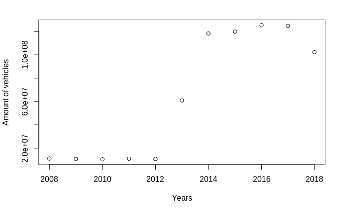

```r
volume.per.year <- df %>%
    group_by(PERIODO) %>%
    summarise(CANTIDAD_PASOS = sum(CANTIDAD_PASOS))
plot(volume.per.year$CANTIDAD_PASOS ~ volume.per.year$PERIODO, xlab = 'Years', ylab = 'Amount of vehicles')
```